# 8-0 Domain-specific secondary outcomes

This file runs through the descriptive summaries and analyses of the domain-specific secondary outcomes.

Authors

Affiliations

James Totterdell

University of Sydney

Rob Mahar

University of Melbourne

Published

July 14, 2022

# Preamble

**Load packages**

```r
library(tidyverse)
library(labelled)
library(kableExtra)
library(cmdstanr)
library(posterior)
library(bayestestR)
library(bayesplot)
library(matrixStats)
library(plotly)
library(lubridate)
library(ggdist)
library(patchwork)

theme_set(theme_classic(base_size = 10, base_family = "Palatino") +
  theme(panel.grid = element_blank(),
        strip.background = element_blank()))
bayesplot_theme_set(theme_set(theme_classic(base_size = 10, base_family = "Palatino") +
  theme(panel.grid = element_blank(),
        strip.background = element_blank())))

color_scheme_set("red")
options(digits = 4)
```

```r
logistic_mod <- cmdstan_model("stan/binary/logistic.stan")
primary_mod <- cmdstan_model("stan/binary/logistic_site_epoch.stan")
```

**Prepare dataset**

```r
devtools::load_all()
all_dat <- read_all_no_daily()
all_dat_daily <- read_all_daily()

daily_events <- all_dat_daily %>%
  filter_acs_itt() %>%
  group_by(StudyPatientID) %>%
  summarise(
    dd_mb = as.numeric(any(DD_AE_C_MajorBleedingISTH == "Yes")),
    dd_hit = as.numeric(any(DD_AE_C_HeparinHIT == "Yes"))
  )

acs_itt_dat <- all_dat %>%
  filter_acs_itt() %>%
  left_join(daily_events, by = "StudyPatientID") %>%
  mutate(
    # 8.0 death
    out_dth = D28_death,
    # 8.2 deep vein thrombosis
    out_dvt = case_when(
      D28_ABEventNone == "Yes" ~ 0,
      D28_ABEventUnknown == "Yes" ~ NA_real_,
      D28_ABDeepVein == "Yes" ~ 1,
      TRUE ~ 0
    ),
    # 8.3 - pulmonary embolism
    out_pe = case_when(
      D28_ABEventNone == "Yes" ~ 0,
      D28_ABEventUnknown == "Yes" ~ NA_real_,
      D28_ABPulmonaryEmbolism == "Yes" ~ 1,
      TRUE ~ 0
    ),
    # 8.4 - acute myocardial infarction
    out_ami = case_when(
      D28_ABEventNone == "Yes" ~ 0,
      D28_ABEventUnknown == "Yes" ~ NA_real_,
      D28_ABAcuteMyocardinalInfarction == "Yes" ~ 1,
      TRUE ~ 0
    ),
    # 8.5 - ischemic cerebrovascular event
    out_ice = case_when(
      D28_ABEventNone == "Yes" ~ 0,
      D28_ABEventUnknown == "Yes" ~ NA_real_,
      D28_ABIschemicCerebrovascularEvent == "Yes" ~ 1,
      TRUE ~ 0
    ),
    # 8.10 - other confirmed thrombotic event
    out_ote = case_when(
      D28_ABEventNone == "Yes" ~ 0,
      D28_ABEventUnknown == "Yes" ~ NA_real_,
      D28_ABOtherThromboEvent == "Yes" ~ 1,
      TRUE ~ 0
    ),
    # Any thrombotic event
    out_ate = case_when(
      out_dvt == 1 | out_pe == 1 | out_ami == 1  | out_ice == 1 | out_ote == 1 ~ 1,
      is.na(out_dvt) | is.na(out_pe) | is.na(out_ami) | is.na(out_ice) | is.na(out_ote) ~ NA_real_,
      out_dvt == 0 & out_pe == 0 & out_ami == 0  & out_ice == 0 & out_ote == 0 ~ 0
    ),
    # 8.1 - any thrombotic event or death
    out_ated = case_when(
      out_dth == 1 | out_dvt == 1 | out_pe == 1 | out_ami == 1  | out_ice == 1 | out_ote == 1 ~ 1,
      is.na(out_dth) | is.na(out_dvt) | is.na(out_pe) | is.na(out_ami) | is.na(out_ice) | is.na(out_ote) ~ NA_real_,
      out_dth == 0 & out_dvt == 0 & out_pe == 0 & out_ami == 0  & out_ice == 0 & out_ote == 0 ~ 0
    ),
    # 8.7 - major bleeding
    out_mb = case_when(
      dd_mb == 1 ~ 1, # from daily data
      D28_AECNone == "Yes" ~ 0,
      D28_AECMajorBleeding == "No" ~ 0,
      D28_AECMajorBleeding == "Yes" ~ 1,
      D28_AECUnknown == "Yes" ~ NA_real_,
      TRUE ~ 0
    ),
    # 8.8 - non-major bleeding
    out_nmb = case_when(
      D28_ABNonMajorBleeding == "Yes" ~ 1,
      D28_ABNonMajorBleeding == "No" ~ 0,
      D28_ABNonMajorBleeding == "Unknown" ~ NA_real_
    ),
    # 8.6 - any clinically relevant bleeding
    out_crb = case_when(
      out_mb == 1 | out_nmb == 1 ~ 1,
      is.na(out_mb) | is.na(out_nmb) ~ NA_real_,
      out_mb == 0 & out_nmb == 0 ~ 0
    ),
    # 8.9 - heparin-induced thrombocytopenia
    out_hit = case_when(
      dd_hit == 1 ~ 1, # from daily data
      D28_AECNone == "Yes" ~ 0,
      D28_AECUnknown == "Yes" ~ NA_real_,
      D28_AECHIT == "Yes" ~ 1,
      TRUE ~ 0
    )
  )
```

```r
acs_itt_dat %>% dplyr::count(out_dvt, D28_ABDeepVein, D28_ABEventNone, D28_ABEventUnknown)
```

```
# A tibble: 4 × 5
  out_dvt D28_ABDeepVein D28_ABEventNone D28_ABEventUnknown     n
    <dbl> <chr>          <chr>           <chr>              <int>
1       0 <NA>           Yes             <NA>                1511
2       0 <NA>           <NA>            <NA>                   5
3       1 Yes            <NA>            <NA>                   1
4      NA <NA>           <NA>            Yes                   39
```

```r
acs_itt_dat %>% dplyr::count(out_pe, D28_ABPulmonaryEmbolism, D28_ABEventNone, D28_ABEventUnknown)
```

```
# A tibble: 4 × 5
  out_pe D28_ABPulmonaryEmbolism D28_ABEventNone D28_ABEventUnknown     n
   <dbl> <chr>                   <chr>           <chr>              <int>
1      0 <NA>                    Yes             <NA>                1511
2      0 <NA>                    <NA>            <NA>                   4
3      1 Yes                     <NA>            <NA>                   2
4     NA <NA>                    <NA>            Yes                   39
```

```r
acs_itt_dat %>% dplyr::count(out_ami, D28_ABAcuteMyocardinalInfarction, D28_ABEventNone, D28_ABEventUnknown)
```

```
# A tibble: 4 × 5
  out_ami D28_ABAcuteMyocardinalInfarcti… D28_ABEventNone D28_ABEventUnkn…     n
    <dbl> <chr>                           <chr>           <chr>            <int>
1       0 <NA>                            Yes             <NA>              1511
2       0 <NA>                            <NA>            <NA>                 4
3       1 Yes                             <NA>            <NA>                 2
4      NA <NA>                            <NA>            Yes                 39
```

```r
acs_itt_dat %>% dplyr::count(out_ice, D28_ABIschemicCerebrovascularEvent, D28_ABEventNone, D28_ABEventUnknown)
```

```
# A tibble: 3 × 5
  out_ice D28_ABIschemicCerebrovascularE… D28_ABEventNone D28_ABEventUnkn…     n
    <dbl> <chr>                           <chr>           <chr>            <int>
1       0 <NA>                            Yes             <NA>              1511
2       0 <NA>                            <NA>            <NA>                 6
3      NA <NA>                            <NA>            Yes                 39
```

```r
acs_itt_dat %>% dplyr::count(out_ote, D28_ABOtherThromboEvent, D28_ABEventNone, D28_ABEventUnknown)
```

```
# A tibble: 4 × 5
  out_ote D28_ABOtherThromboEvent D28_ABEventNone D28_ABEventUnknown     n
    <dbl> <chr>                   <chr>           <chr>              <int>
1       0 <NA>                    Yes             <NA>                1511
2       0 <NA>                    <NA>            <NA>                   5
3       1 Yes                     <NA>            <NA>                   1
4      NA <NA>                    <NA>            Yes                   39
```

```r
acs_itt_dat %>% dplyr::count(out_ated, out_dth, out_dvt, out_pe, out_ami, out_ice, out_ote)
```

```
# A tibble: 11 × 8
   out_ated out_dth out_dvt out_pe out_ami out_ice out_ote     n
      <dbl>   <int>   <dbl>  <dbl>   <dbl>   <dbl>   <dbl> <int>
 1        0       0       0      0       0       0       0  1465
 2        1       0       0      0       0       0       1     1
 3        1       0       0      0       1       0       0     1
 4        1       0       0      1       0       0       0     2
 5        1       0       1      0       0       0       0     1
 6        1       1       0      0       0       0       0    43
 7        1       1       0      0       1       0       0     1
 8        1       1      NA     NA      NA      NA      NA     6
 9       NA       0      NA     NA      NA      NA      NA    10
10       NA      NA       0      0       0       0       0     3
11       NA      NA      NA     NA      NA      NA      NA    23
```

```r
acs_itt_dat %>% dplyr::count(D28_AECHIT, D28_AECMajorBleeding, D28_AECNone, D28_AECUnknown)
```

```
# A tibble: 3 × 5
  D28_AECHIT D28_AECMajorBleeding D28_AECNone D28_AECUnknown     n
  <chr>      <chr>                <chr>       <chr>          <int>
1 <NA>       No                   Yes         <NA>            1512
2 <NA>       No                   <NA>        Yes               43
3 <NA>       Yes                  <NA>        <NA>               1
```

```r
acs_itt_dat %>% dplyr::count(out_mb, D28_AECMajorBleeding, D28_AECNone, D28_AECUnknown)
```

```
# A tibble: 5 × 5
  out_mb D28_AECMajorBleeding D28_AECNone D28_AECUnknown     n
   <dbl> <chr>                <chr>       <chr>          <int>
1      0 No                   Yes         <NA>            1508
2      0 No                   <NA>        Yes               42
3      1 No                   Yes         <NA>               4
4      1 No                   <NA>        Yes                1
5      1 Yes                  <NA>        <NA>               1
```

```r
acs_itt_dat %>% dplyr::count(out_nmb, D28_ABNonMajorBleeding)
```

```
# A tibble: 3 × 3
  out_nmb D28_ABNonMajorBleeding     n
    <dbl> <chr>                  <int>
1       0 No                      1513
2       1 Yes                        8
3      NA Unknown                   35
```

```r
acs_itt_dat %>% dplyr::count(out_crb, out_mb, out_nmb)
```

```
# A tibble: 6 × 4
  out_crb out_mb out_nmb     n
    <dbl>  <dbl>   <dbl> <int>
1       0      0       0  1510
2       1      0       1     6
3       1      1       0     3
4       1      1       1     2
5       1      1      NA     1
6      NA      0      NA    34
```

```r
acs_itt_dat %>% dplyr::count(out_hit, D28_AECHIT, D28_AECNone, D28_AECUnknown)
```

```
# A tibble: 4 × 5
  out_hit D28_AECHIT D28_AECNone D28_AECUnknown     n
    <dbl> <chr>      <chr>       <chr>          <int>
1       0 <NA>       Yes         <NA>            1511
2       0 <NA>       <NA>        <NA>               1
3       1 <NA>       Yes         <NA>               1
4      NA <NA>       <NA>        Yes               43
```

# Descriptive

## Anticoagulation

The following table describes the anticoagulation domain-specific outcomes by anticoagulation intervention.

```r
gtab <- acs_itt_dat %>%
  select(CAssignment, out_dth,
         out_ated, out_ate, out_dvt, out_pe, out_ami, out_ice, out_ote,
         out_crb, out_mb, out_nmb, out_hit) %>%
  group_by(CAssignment) %>%
  summarise(
    Randomised_ = n(),
    `Mortality_Died by day 28` = sprintf("%i (%.0f)", sum(out_dth, na.rm = TRUE), 100 * mean(out_dth, na.rm = TRUE)),
    `Mortality_Unknown` = sprintf("%i (%.0f)", sum(is.na(out_dth)), 100 * mean(is.na(out_dth))),
    `Thrombotic events_Unknown` =
        sprintf("%i (%.0f)", sum(is.na(out_dvt)), 100 * mean(is.na(out_dvt))),
    `Thrombotic events_Deep vein thrombosis` =
      sprintf("%i (%.0f)", sum(out_dvt, na.rm = TRUE), 100 * mean(out_dvt, na.rm = TRUE)),
    `Thrombotic events_Pulmonary embolus` =
      sprintf("%i (%.0f)", sum(out_pe, na.rm = TRUE), 100 * mean(out_pe, na.rm = TRUE)),
    `Thrombotic events_Acute myocardial infarction` =
      sprintf("%i (%.0f)", sum(out_ami, na.rm = TRUE), 100 * mean(out_ami, na.rm = TRUE)),
    `Thrombotic events_Ischemic cerebrovascular event` =
      sprintf("%i (%.0f)", sum(out_ice, na.rm = TRUE), 100 * mean(out_ice, na.rm = TRUE)),
    `Thrombotic events_Other confirmed thrombotic event` =
      sprintf("%i (%.0f)", sum(out_ote, na.rm = TRUE), 100 * mean(out_ote, na.rm = TRUE)),
    `Thrombotic events_Any thrombotic event` =
      sprintf("%i (%.0f)", sum(out_ate, na.rm = TRUE), 100 * mean(out_ate, na.rm = TRUE)),
    `Thrombotic events_Any thrombotic event or death` =
      sprintf("%i (%.0f)", sum(out_ated, na.rm = TRUE), 100 * mean(out_ated, na.rm = TRUE)),
    `Bleeding_Unknown` =
      sprintf("%i (%.0f)", sum(is.na(out_crb)), 100 * mean(is.na(out_crb))),
    `Bleeding_Major bleeding (as defined by ISTH)` =
      sprintf("%i (%.0f)", sum(out_mb, na.rm = TRUE), 100 * mean(out_mb, na.rm = TRUE)),
    `Bleeding_Clinically relevant non-major bleeding` =
      sprintf("%i (%.0f)", sum(out_nmb, na.rm = TRUE), 100 * mean(out_nmb, na.rm = TRUE)),
    `Bleeding_Any clinically relevant bleeding` =
      sprintf("%i (%.0f)", sum(out_crb, na.rm = TRUE), 100 * mean(out_crb, na.rm = TRUE)),
    `Bleeding_Heparin-induced thrombocytopenia` =
      sprintf("%i (%.0f)", sum(out_hit, na.rm = TRUE), 100 * mean(out_hit, na.rm = TRUE)),
  ) %>%
  gather(key, value, -CAssignment, factor_key = TRUE) %>%
  spread(CAssignment, value) %>%
  separate(key, c("Type", "Outcome"), sep = "_")
colnames(gtab)[-(1:2)] <- paste0(intervention_labels()$CAssignment[-1], "<br>(n = ", gtab[1, -(1:2)], ")")
gtab <- gtab[-1, ]

otab <- acs_itt_dat %>%
  select(CAssignment, out_dth,
         out_ated, out_ate, out_dvt, out_pe, out_ami, out_ice, out_ote,
         out_crb, out_mb, out_nmb, out_hit) %>%
  group_by(CAssignment = "Overall") %>%
  summarise(
    Randomised_ = n(),
    `Mortality_Died by day 28` = sprintf("%i (%.0f)", sum(out_dth, na.rm = TRUE), 100 * mean(out_dth, na.rm = TRUE)),
    `Mortality_Unknown` = sprintf("%i (%.0f)", sum(is.na(out_dth)), 100 * mean(is.na(out_dth))),
    `Thrombotic events_Unknown` =
        sprintf("%i (%.0f)", sum(is.na(out_dvt)), 100 * mean(is.na(out_dvt))),
    `Thrombotic events_Deep vein thrombosis` =
      sprintf("%i (%.0f)", sum(out_dvt, na.rm = TRUE), 100 * mean(out_dvt, na.rm = TRUE)),
    `Thrombotic events_Pulmonary embolus` =
      sprintf("%i (%.0f)", sum(out_pe, na.rm = TRUE), 100 * mean(out_pe, na.rm = TRUE)),
    `Thrombotic events_Acute myocardial infarction` =
      sprintf("%i (%.0f)", sum(out_ami, na.rm = TRUE), 100 * mean(out_ami, na.rm = TRUE)),
    `Thrombotic events_Ischemic cerebrovascular event` =
      sprintf("%i (%.0f)", sum(out_ice, na.rm = TRUE), 100 * mean(out_ice, na.rm = TRUE)),
    `Thrombotic events_Other confirmed thrombotic event` =
      sprintf("%i (%.0f)", sum(out_ote, na.rm = TRUE), 100 * mean(out_ote, na.rm = TRUE)),
    `Thrombotic events_Any thrombotic event` =
      sprintf("%i (%.0f)", sum(out_ate, na.rm = TRUE), 100 * mean(out_ate, na.rm = TRUE)),
    `Thrombotic events_Any thrombotic event or death` =
      sprintf("%i (%.0f)", sum(out_ated, na.rm = TRUE), 100 * mean(out_ated, na.rm = TRUE)),
    `Bleeding_Unknown` =
      sprintf("%i (%.0f)", sum(is.na(out_crb)), 100 * mean(is.na(out_crb))),
    `Bleeding_Major bleeding (as defined by ISTH)` =
      sprintf("%i (%.0f)", sum(out_mb, na.rm = TRUE), 100 * mean(out_mb, na.rm = TRUE)),
    `Bleeding_Clinically relevant non-major bleeding` =
      sprintf("%i (%.0f)", sum(out_nmb, na.rm = TRUE), 100 * mean(out_nmb, na.rm = TRUE)),
    `Bleeding_Any clinically relevant bleeding` =
      sprintf("%i (%.0f)", sum(out_crb, na.rm = TRUE), 100 * mean(out_crb, na.rm = TRUE)),
    `Bleeding_Heparin-induced thrombocytopenia` =
      sprintf("%i (%.0f)", sum(out_hit, na.rm = TRUE), 100 * mean(out_hit, na.rm = TRUE)),
  ) %>%
  gather(key, value, -CAssignment, factor_key = TRUE) %>%
  spread(CAssignment, value) %>%
  separate(key, c("Type", "Outcome"), sep = "_")
colnames(otab)[-(1:2)] <- paste0("Overall<br>(n = ", otab[1, -(1:2)], ")")
otab <- otab[-1, ]

tab <- left_join(gtab, otab, by = c("Type", "Outcome"))
colnames(tab)[2] <- "Outcome, n (\\%)"

kable(
  tab[, -1],
  booktabs = TRUE,
  align = "lrrrrr",
  escape = F
) %>%
  kable_styling(
    latex_options = "HOLD_position"
  ) %>%
  pack_rows("Mortality", 1, 2) %>%
  pack_rows("Thrombotic events", 3, 10) %>%
  pack_rows("Bleeding", 11, 15)
```

| Outcome, n (\%) | Low dose (n = 610) | Intermediate dose (n = 613) | Low dose with aspirin (n = 283) | Therapeutic dose (n = 50) | Overall (n = 1556) |
| --- | --- | --- | --- | --- | --- |
| **Mortality** |  |  |  |  |  |
| Died by day 28 | 19 (3) | 15 (2) | 10 (4) | 6 (12) | 50 (3) |
| Unknown | 14 (2) | 10 (2) | 2 (1) | 0 (0) | 26 (2) |
| **Thrombotic events** |  |  |  |  |  |
| Unknown | 18 (3) | 14 (2) | 5 (2) | 2 (4) | 39 (3) |
| Deep vein thrombosis | 1 (0) | 0 (0) | 0 (0) | 0 (0) | 1 (0) |
| Pulmonary embolus | 0 (0) | 1 (0) | 1 (0) | 0 (0) | 2 (0) |
| Acute myocardial infarction | 1 (0) | 1 (0) | 0 (0) | 0 (0) | 2 (0) |
| Ischemic cerebrovascular event | 0 (0) | 0 (0) | 0 (0) | 0 (0) | 0 (0) |
| Other confirmed thrombotic event | 1 (0) | 0 (0) | 0 (0) | 0 (0) | 1 (0) |
| Any thrombotic event | 3 (1) | 2 (0) | 1 (0) | 0 (0) | 6 (0) |
| Any thrombotic event or death | 21 (4) | 17 (3) | 11 (4) | 6 (12) | 55 (4) |
| **Bleeding** |  |  |  |  |  |
| Unknown | 15 (2) | 13 (2) | 4 (1) | 2 (4) | 34 (2) |
| Major bleeding (as defined by ISTH) | 1 (0) | 2 (0) | 3 (1) | 0 (0) | 6 (0) |
| Clinically relevant non-major bleeding | 2 (0) | 2 (0) | 2 (1) | 2 (4) | 8 (1) |
| Any clinically relevant bleeding | 3 (1) | 4 (1) | 3 (1) | 2 (4) | 12 (1) |
| Heparin-induced thrombocytopenia | 0 (0) | 1 (0) | 0 (0) | 0 (0) | 1 (0) |

```r
colnames(tab) <- linebreak(colnames(tab), align = "c", linebreaker = "<br>")
out <- kable(
  tab[, -1],
  format = "latex",
  booktabs = TRUE,
  align = "lrrrrrr",
  escape = FALSE
) %>%
  kable_styling(
    font_size = 9,
    latex_options = "HOLD_position"
  ) %>%
  pack_rows("Mortality", 1, 2) %>%
  pack_rows("Thrombotic events", 3, 10) %>%
  pack_rows("Bleeding", 11, 15)
save_tex_table(out, file.path("outcomes", "secondary", "8-0-anticoagulation-specific-summary"))
```

# Modelling

The SAP only requests formal analyses of the two composite outcomes:

- any thrombotic event or death
- any clinically relevant bleeding

The analysis of any thrombotic event or death will largely be driven by death due to the small number of thrombotic events. Therefore, the result is likely to be similar to that obtained for all-cause mortality. In any event, this analysis is undertaken below.

## Primary Model

```r
acs_itt_nona_dat <- acs_itt_dat %>%
  filter(!is.na(out_ated)) %>%
  transmute_model_cols_grp_aus_nz() %>%
  left_join(acs_itt_dat %>%
              select(StudyPatientID, out_ated),
            by = "StudyPatientID")

ctr <- contr.orthonorm
X <- make_X_design(acs_itt_nona_dat, c("inelgc3", "agegte60", "ctry"), ctr)
nXassign <- sum(grepl("rand", colnames(X))) - 1
epoch  <- acs_itt_nona_dat$epoch
M_epoch  <- max(acs_itt_nona_dat$epoch)
region <- acs_itt_nona_dat[["ctry_num"]]
M_region <- max(region)
site <- acs_itt_nona_dat[["site_num"]]
M_site <- max(site)
region_by_site <- region_by_site <- acs_itt_nona_dat %>%
  dplyr::count(ctry_num, site_num) %>%
  pull(ctry_num)
epoch_map <- acs_itt_nona_dat %>% dplyr::count(epoch, epoch_lab)
site_map <- acs_itt_nona_dat %>% dplyr::count(site_num, site)

mdat <- list(N = nrow(X), K = ncol(X), X = X, y = acs_itt_nona_dat$out_ated,
       M_region = M_region, M_site = M_site, site = site,
       M_epoch = M_epoch, epoch = epoch,
       region_by_site = region_by_site,
       beta_sd = c(2.5, rep(1, nXassign), 10, 2.5, rep(1, 2)))

snk <- capture.output(
  mfit <- primary_mod$sample(
    data = mdat,
    seed = 28497,
    refresh = 0,
    iter_warmup = 1000,
    iter_sampling = 2500,
    chains = 8,
    parallel_chains = 8,
    adapt_delta = 0.98
))
drws <- as_draws_rvars(mfit$draws(c("beta", "gamma_epoch", "gamma_site", "tau_epoch", "tau_site")))

names(drws$beta) <- colnames(X)
names(drws$gamma_epoch) <- epoch_map$epoch_lab
names(drws$gamma_site) <- site_map$site

drws$Acon <- attr(X, "contrasts")$randA %**% drws$beta[6]
drws$Ccon <- attr(X, "contrasts")$randC %**% drws$beta[2:4]
drws$Atrt <- drws$Acon[-1] - drws$Acon[1]
drws$Ctrt <- drws$Ccon[-1] - drws$Ccon[1]

drws$treat <- (transform_coding(cbind(1, contr.orthonorm(4)), cbind(1, contr.treatment(4))) %**%
  drws$beta[1:4])[2:4]

drws$OR <- exp(c(
  drws$treat,
  drws$beta[7],
  drws$beta[8],
  drws$beta[9:10]))
names(drws$OR) <- c(
  "Intermediate", "Low with aspirin", "Therapeutic",
  "Ineligible aspirin", "Age \u2265 60",
  "Australia/NZ", "Nepal")
```

```r
save_tex_table(
  odds_ratio_summary_table(drws$OR, "latex"),
  "outcomes/secondary/8-1-primary-model-acs-itt-summary-table")
odds_ratio_summary_table(drws$OR)
```

| Parameter | Median | 95% CrI | Mean (SD) | Pr(OR < 1) |
| --- | --- | --- | --- | --- |
| Intermediate | 0.85 | (0.44, 1.65) | 0.90 (0.31) | 0.68 |
| Low with aspirin | 0.87 | (0.39, 1.90) | 0.94 (0.39) | 0.64 |
| Therapeutic | 2.47 | (0.82, 7.47) | 2.91 (1.84) | 0.06 |
| Ineligible aspirin | 4.66 | (1.18, 15.91) | 5.65 (3.94) | 0.01 |
| Age ≥ 60 | 2.06 | (1.14, 3.75) | 2.15 (0.66) | 0.01 |
| Australia/NZ | 0.96 | (0.22, 3.94) | 1.25 (1.03) | 0.52 |
| Nepal | 2.51 | (0.56, 9.18) | 3.11 (2.41) | 0.10 |

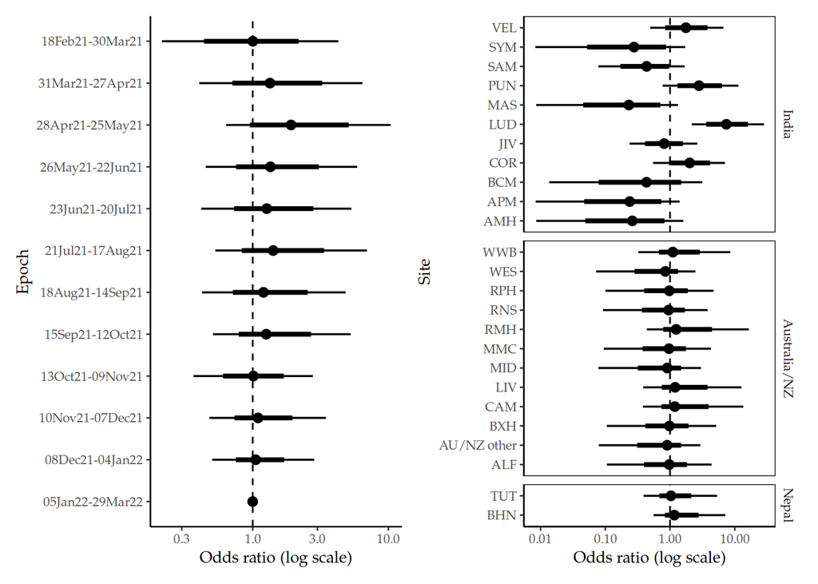

```r
epoch_rvs <- exp(drws$gamma_epoch)
site_rvs <- exp(drws$gamma_site)
facets <- factor(mdat$region_by_site, labels = c("India", "Australia/NZ", "Nepal"))
p <- plot_epoch_site_terms(epoch_rvs, site_rvs, facets)
pth <- file.path("outputs", "figures", "outcomes", "secondary", "8-1-primary-model-epoch-site-terms.pdf")
ggsave(pth, p, width = 6, height = 4.5)
p
```

### Prior Sensitivity

The analysis is repeated using treatment coding rather than the orthonormal coding. Due to the change in prior, the is a slight shift in the estimated treatment effects, however this does not alter the result of weak evidence for any difference.

```r
ctr <- contr.treatment
X <- make_X_design(acs_itt_nona_dat, c("inelgc3", "agegte60", "ctry"), ctr)
nXassign <- sum(grepl("rand", colnames(X))) - 1
epoch  <- acs_itt_nona_dat$epoch
M_epoch  <- max(acs_itt_nona_dat$epoch)
region <- acs_itt_nona_dat[["ctry_num"]]
M_region <- max(region)
site <- acs_itt_nona_dat[["site_num"]]
M_site <- max(site)
region_by_site <- region_by_site <- acs_itt_nona_dat %>%
  dplyr::count(ctry_num, site_num) %>%
  pull(ctry_num)
epoch_map <- acs_itt_nona_dat %>% dplyr::count(epoch, epoch_lab)
site_map <- acs_itt_nona_dat %>% dplyr::count(site_num, site)

mdat <- list(N = nrow(X), K = ncol(X), X = X, y = acs_itt_nona_dat$out_ated,
       M_region = M_region, M_site = M_site, site = site,
       M_epoch = M_epoch, epoch = epoch,
       region_by_site = region_by_site,
       beta_sd = c(2.5, rep(1, nXassign), 10, 2.5, rep(1, 2)))

snk <- capture.output(
  mfit <- primary_mod$sample(
    data = mdat,
    seed = 28497,
    refresh = 0,
    iter_warmup = 1000,
    iter_sampling = 2500,
    chains = 8,
    parallel_chains = 8,
    adapt_delta = 0.98
))
drws <- as_draws_rvars(mfit$draws(c("beta", "gamma_epoch", "gamma_site", "tau_epoch", "tau_site")))

names(drws$beta) <- colnames(X)
names(drws$gamma_epoch) <- epoch_map$epoch_lab
names(drws$gamma_site) <- site_map$site

drws$OR <- exp(c(rvar(0), drws$beta[2:4], rvar(0), drws$beta[7], rvar(0), drws$beta[8], rvar(0), drws$beta[9:10]))
names(drws$OR) <- c(
  "Standard (ref)", "Intermediate", "Standard plus aspirin", "Therapeutic",
  "Age < 60 (ref)", "Age 60+", "Eligible aspirin (ref)", "Ineligible aspirin",
  "India (ref)", "Australia/NZ", "Nepal")
```

```r
odds_ratio_summary_table(drws$OR)
```

| Parameter | Median | 95% CrI | Mean (SD) | Pr(OR < 1) |
| --- | --- | --- | --- | --- |
| Standard (ref) | 1.00 | (1.00, 1.00) | 1.00 (0.00) | 0.00 |
| Intermediate | 0.81 | (0.42, 1.51) | 0.85 (0.28) | 0.75 |
| Standard plus aspirin | 0.81 | (0.38, 1.70) | 0.87 (0.34) | 0.70 |
| Therapeutic | 2.23 | (0.75, 6.35) | 2.57 (1.48) | 0.07 |
| Age < 60 (ref) | 1.00 | (1.00, 1.00) | 1.00 (0.00) | 0.00 |
| Age 60+ | 4.62 | (1.20, 15.95) | 5.61 (3.96) | 0.01 |
| Eligible aspirin (ref) | 1.00 | (1.00, 1.00) | 1.00 (0.00) | 0.00 |
| Ineligible aspirin | 2.06 | (1.13, 3.78) | 2.16 (0.68) | 0.01 |
| India (ref) | 1.00 | (1.00, 1.00) | 1.00 (0.00) | 0.00 |
| Australia/NZ | 0.91 | (0.20, 3.77) | 1.18 (0.99) | 0.55 |
| Nepal | 2.53 | (0.59, 9.03) | 3.12 (2.32) | 0.10 |

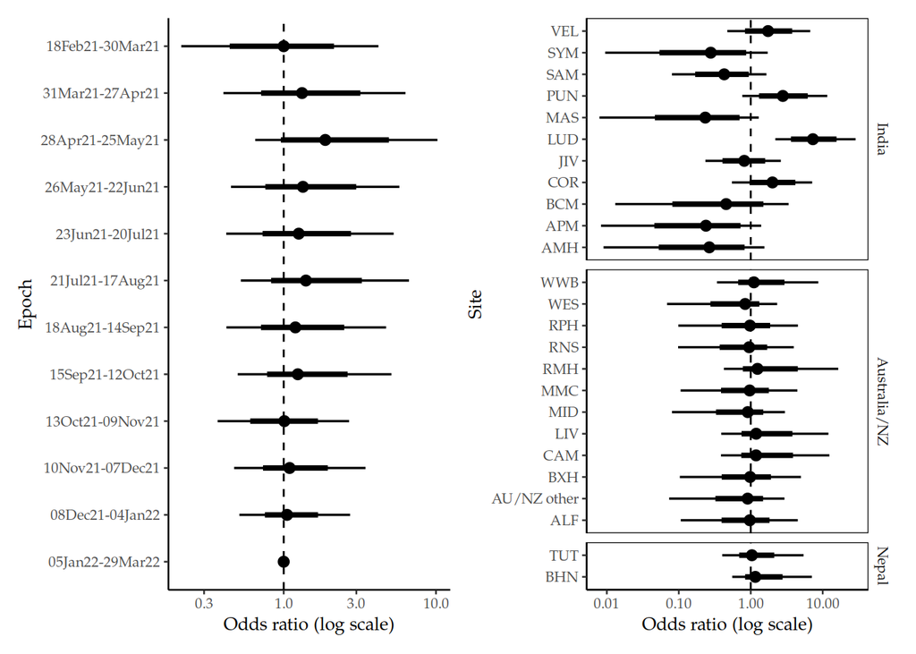

```r
epoch_rvs <- exp(drws$gamma_epoch)
site_rvs <- exp(drws$gamma_site)
facets <- factor(mdat$region_by_site, labels = c("India", "Australia/NZ", "Nepal"))
p <- plot_epoch_site_terms(epoch_rvs, site_rvs, facets)
p
```